# GLM model vs Cox

Problem:

1. Estimate the Cox model with constant baseline hazard rate for the (German Breast Cancer Study Group 2)- GBSG2 from package “TH.data”" using the function glm() and compare the results to the ones from the function survreg().

Hint: Results from the Cox-PH with constant baseline are equivalent to results of an Exponential-AFT model. W.K.T Beta_cox = - Beta_AFT (if scale(sigma/ dispersion parameter)=1)

2. Model diagnosis of Cox Ph model using residuals

Data set details:

horTh-hormonal therapy, a factor at two levels no and yes. age-of the patients in years. menostat-menopausal status, a factor at two levels pre (premenopausal) and post (postmenopausal). tsize-tumor size (in mm). tgrade-tumor grade, a ordered factor at levels I < II < III. pnodes-number of positive nodes. progrec-progesterone receptor (in fmol). estrec-estrogen receptor (in fmol). time-recurrence free survival time (in days). cens-censoring indicator (0- censored, 1- event).

```r
library(dplyr)
data(GBSG2,package="TH.data")
head(GBSG2)
```

|  | horTh | age | menostat | tsize | tgrade | pnodes | progrec | estrec | time | cens |
| --- | --- | --- | --- | --- | --- | --- | --- | --- | --- | --- |
| 1 | no | 70 | Post | 21 | II | 3 | 48 | 66 | 1814 | 1 |
| 2 | yes | 56 | Post | 12 | II | 7 | 61 | 77 | 2018 | 1 |
| 3 | yes | 58 | Post | 35 | II | 9 | 52 | 271 | 712 | 1 |
| 4 | yes | 59 | Post | 17 | II | 4 | 60 | 29 | 1807 | 1 |
| 5 | no | 73 | Post | 35 | II | 1 | 26 | 65 | 772 | 1 |
| 6 | no | 32 | Pre | 57 | III | 24 | 0 | 13 | 448 | 1 |

## 1. GLM model (log-linear poisson model)

```r
glm_model<- glm(cens~1, family = poisson(link = "log"), offset = log(time), data = GBSG2)
summary(glm_model)
```

```
Call:
glm(formula = cens ~ 1, family = poisson(link = "log"), data = GBSG2,
    offset = log(time))

Deviance Residuals:
    Min       1Q   Median       3Q      Max
-1.4357  -1.1071  -0.6851   1.0219   2.2833

Coefficients:
            Estimate Std. Error z value Pr(>|z|)
(Intercept) -7.85552    0.05783  -135.8   <2e-16 ***
---
Signif. codes:  0 ‘***’ 0.001 ‘**’ 0.01 ‘*’ 0.05 ‘.’ 0.1 ‘ ’ 1

(Dispersion parameter for poisson family taken to be 1)

    Null deviance: 822.49  on 685  degrees of freedom
Residual deviance: 822.49  on 685  degrees of freedom
AIC: 1422.5

Number of Fisher Scoring iterations: 6
```

```r
lambda_GLM<- exp(glm_model$coefficients)
print(paste("GLM Lambda value:",lambda_GLM))
```

```
[1] "GLM Lambda value: 0.000387606948405752"
```

## COX Model (Exponential)

```r
library(survival)
aft_model<- survreg(Surv(time,cens)~1, dist = "exponential", data = GBSG2)
summary(aft_model)
```

```
Call:
survreg(formula = Surv(time, cens) ~ 1, data = GBSG2, dist = "exponential")
             Value Std. Error   z      p
(Intercept) 7.8555     0.0578 136 <2e-16

Scale fixed at 1

Exponential distribution
Loglik(model)= -2647.8   Loglik(intercept only)= -2647.8
Number of Newton-Raphson Iterations: 4
n= 686
```

```r
lambda_COX<- exp(-aft_model$coefficients)
print(paste("COX Lambda value:",lambda_COX))
```

```
[1] "COX Lambda value: 0.000387606948465559"
```

Thus both the Beta coefficient of Exponential Cox model and the GLM model is same.

Comparing again both by adding addition covariates

```r
glm_model<- glm(cens~1 + horTh + tsize + progrec + estrec + menostat,
                family = poisson(link = "log"), offset = log(time), data = GBSG2)
summary(glm_model)
```

```
Call:
glm(formula = cens ~ 1 + horTh + tsize + progrec + estrec + menostat,
    family = poisson(link = "log"), data = GBSG2, offset = log(time))

Deviance Residuals:
    Min       1Q   Median       3Q      Max
-1.8227  -1.0033  -0.5240   0.9523   2.4663

Coefficients:
               Estimate Std. Error z value Pr(>|z|)
(Intercept)  -8.043e+00  1.563e-01 -51.462  < 2e-16 ***
horThyes     -3.679e-01  1.280e-01  -2.876  0.00403 **
tsize         1.524e-02  3.596e-03   4.239 2.24e-05 ***
progrec      -2.585e-03  5.792e-04  -4.463 8.10e-06 ***
estrec        7.556e-05  4.714e-04   0.160  0.87264
menostatPost  1.554e-01  1.247e-01   1.246  0.21263
---
Signif. codes:  0 ‘***’ 0.001 ‘**’ 0.01 ‘*’ 0.05 ‘.’ 0.1 ‘ ’ 1

(Dispersion parameter for poisson family taken to be 1)

    Null deviance: 822.49  on 685  degrees of freedom
Residual deviance: 765.96  on 680  degrees of freedom
AIC: 1376

Number of Fisher Scoring iterations: 6
```

```r
lambda_GLM<- exp(glm_model$coefficients)
print(lambda_GLM)
```

```
 (Intercept)     horThyes        tsize      progrec       estrec menostatPost
0.0003214781 0.6921560440 1.0153597609 0.9974187336 1.0000755624 1.1681472281
```

```r
aft_model<- survreg(Surv(time,cens) ~ 1 + horTh + tsize + progrec + estrec + menostat,
                    dist = "exponential", data = GBSG2)
summary(aft_model)
```

```
Call:
survreg(formula = Surv(time, cens) ~ 1 + horTh + tsize + progrec +
    estrec + menostat, data = GBSG2, dist = "exponential")
                 Value Std. Error     z       p
(Intercept)   8.04e+00   1.56e-01 51.46 < 2e-16
horThyes      3.68e-01   1.28e-01  2.88   0.004
tsize        -1.52e-02   3.60e-03 -4.24 2.2e-05
progrec       2.58e-03   5.79e-04  4.46 8.1e-06
estrec       -7.56e-05   4.71e-04 -0.16   0.873
menostatPost -1.55e-01   1.25e-01 -1.25   0.213

Scale fixed at 1

Exponential distribution
Loglik(model)= -2619.5   Loglik(intercept only)= -2647.8
    Chisq= 56.53 on 5 degrees of freedom, p= 6.3e-11
Number of Newton-Raphson Iterations: 5
n= 686
```

```r
lambda_COX<- exp(-aft_model$coefficients)
print(lambda_COX)
```

```
 (Intercept)     horThyes        tsize      progrec       estrec menostatPost
0.0003214781 0.6921560440 1.0153597609 0.9974187336 1.0000755624 1.1681472281
```

### 2. overall COX-PH model diagnosis

```r
library(survminer)
fit<-coxph(Surv(time,cens) ~ horTh + tsize + progrec + estrec + menostat+age,data = GBSG2)
cox.zph(fit)
```

```
          chisq df      p
horTh     0.300  1 0.5838
tsize     0.873  1 0.3501
progrec   5.938  1 0.0148
estrec    5.867  1 0.0154
menostat  5.465  1 0.0194
age       9.899  1 0.0017
GLOBAL   16.814  6 0.0100
```

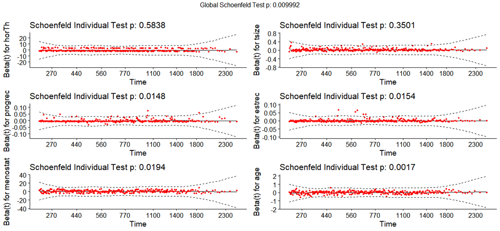

```r
#Proportional Hazard assumption - Schoenfeld residuals
ggcoxzph(cox.zph(fit))
```

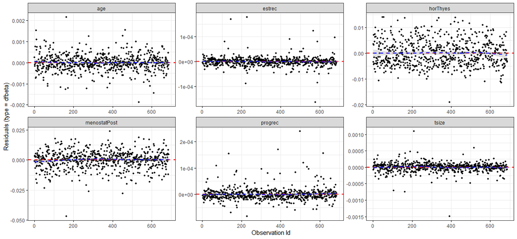

```r
# Testing influential observation - Deviance and dfbets residuals
ggcoxdiagnostics(fit, type= "dfbeta", ggtheme= theme_bw(), linear.predictions = F)
```

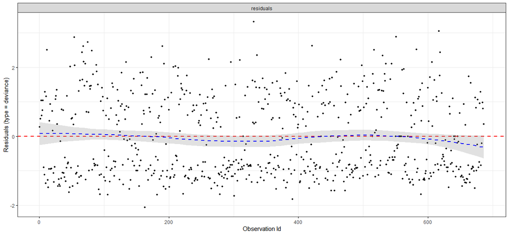

```r
ggcoxdiagnostics(fit, type= "deviance", ggtheme= theme_bw(), linear.predictions = F)
```

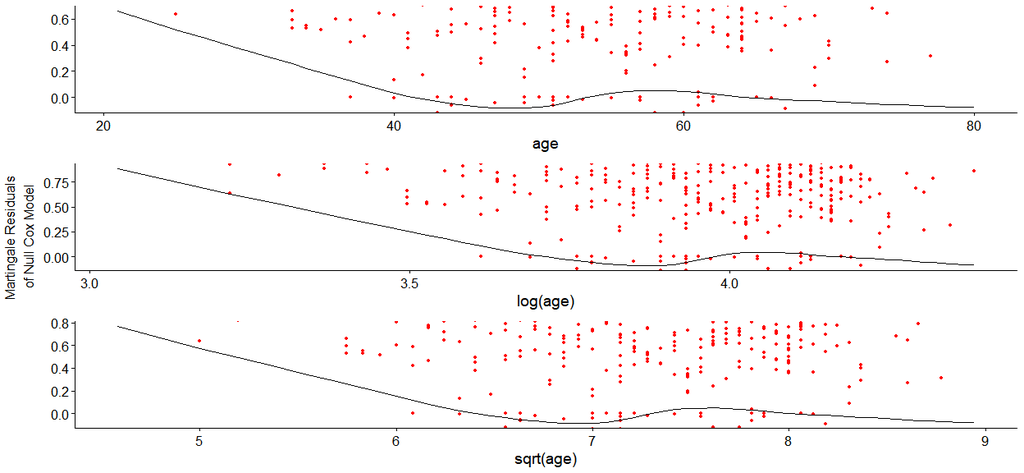

```r
#Testing of non-linearity - Martingale residuals
ggcoxfunctional(Surv(time, cens) ~ age+ log(age)+ sqrt(age), data = GBSG2)
```

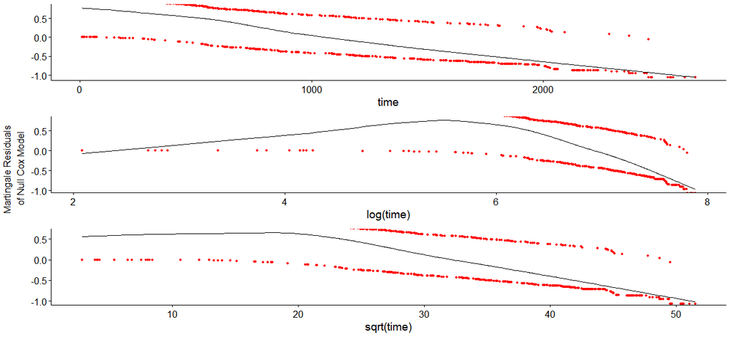

```r
ggcoxfunctional(Surv(time, cens) ~ time+ log(time)+ sqrt(time), data = GBSG2)
```

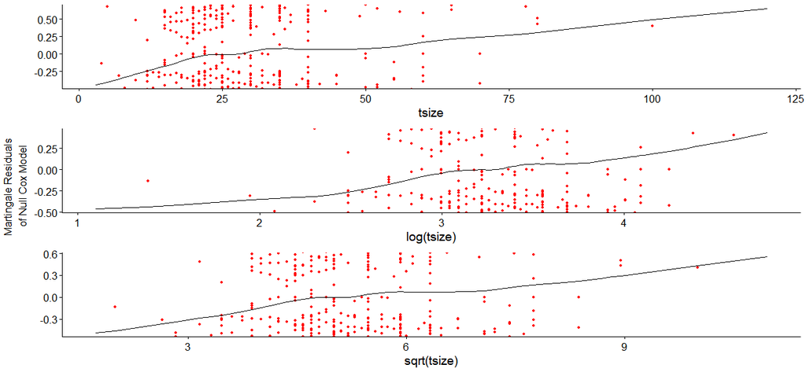

```r
ggcoxfunctional(Surv(time, cens) ~ tsize+ log(tsize)+ sqrt(tsize), data = GBSG2)
```

Conclusion: 1. Proportional Hazard assumption: This model fails the proportional test if we include covariates like estrec, menostat and progrec that has p-value < 0.05, thus we must ignore these covariates and include only tsize and horTh 2. Influential Observation: We could that its is centered around 0 and few outliers are detected 3. Non-linearity testing: Non- linearity of Age and Time is tested and we could see non-linearity in the continuous variable